# ALTSCHULER FLORENCIA

Mayo de 2022

# Trabajo Práctico 1

## Librerias, Entorno de trabajo y carga de archivo

```r
library(vtable)
library(readxl)
library(data.table) #para transponer la tabla
library(psych)
library(GGally)
library(DescTools)
library(splitstackshape)
library(chisq.posthoc.test)
library(dplyr)
library(grDevices) # Equipos gráficos y soporte para la base y la red de gráficos
library(tcltk)
library(aplpack)
```

```r
library(corrplot)
library(modeest) #para estimar la moda
library(ggplot2)
library(dgof) #para hacer test simil shapiro
library(tcltk2)
library(RColorBrewer)
library("moments")
library(cowplot)
library("modeest")
library(car)
library( "pgirmess" ) #para la prueba de kruscal
```

## Ej. 1

Para la base de datos seleccionada genere una muestra aleatoria estratificada y balanceada por variedad de vino de tamaño n = 2000 utilizando como semilla los últimos tres dígitos del DNI/PASAPORTE

```r
set.seed(262)
Datos <- stratified(Datos, "variedad", 1000) #Devuelve la misma cantidad de tinto que blanco
dim(Datos)
```

```
## [1] 2000   13
```

### Ej. 2

Realice un análisis estadístico de cada una de las variables numéricas para cada variedad de vino. Presente la información en forma tabular y conteniendo las siguientes medidas descriptivas: Cantidad de datos, mínimo, máximo, media, mediana, moda, varianza, desviación estándar, coeficiente de variación, cuartil 1, cuartil 3, rango intercuartílico, MAD, asimetría, curtosis.

```r
columnas <- names(Datos)
columnas <- columnas[1:12]

coef_var <- function(x, na.rm = FALSE) {
  sd(x, na.rm=na.rm) / mean(x, na.rm=na.rm)
}

st(Datos,vars = columnas, summ=c('notNA(x)','min(x)','max(x)', 'mean(x)',
                                 'median(x)','pctile(x)[25]', 'pctile(x)[75]',
                                 "IQR(x)","MAD(x)"),
   summ.names =
     c('N','Minimo','Maximo',"Media","mediana", "perc 25",
       "perc 75","Rango intercuartilico","mad"),
   group = 'variedad', group.long = TRUE,
   title = "analisis estadistico")
```

analisis estadistico

| Variable | N | Minimo | Maximo | Media | mediana | perc 25 | perc 75 | Rango intercuartilico | mad |
| --- | --- | --- | --- | --- | --- | --- | --- | --- | --- |
| variedad: 1 |  |  |  |  |  |  |  |  |  |
| acidez_fija | 1000 | 4.4 | 10.3 | 6.83 | 6.8 | 6.3 | 7.3 | 1 | 0.741 |
| acidez_volatil | 1000 | 0.08 | 1.005 | 0.281 | 0.26 | 0.21 | 0.32 | 0.11 | 0.089 |
| acido_citrico | 1000 | 0 | 1.66 | 0.333 | 0.32 | 0.27 | 0.39 | 0.12 | 0.089 |
| azucar_residual | 1000 | 0.7 | 65.8 | 6.287 | 4.8 | 1.6 | 9.812 | 8.213 | 5.041 |
| cloruros | 1000 | 0.012 | 0.255 | 0.046 | 0.043 | 0.036 | 0.05 | 0.014 | 0.01 |
| anhidrido_sulfuroso_libre | 1000 | 2 | 122.5 | 34.421 | 33 | 22 | 45 | 23 | 16.679 |
| anhidrido_sulfuroso_total | 1000 | 24 | 272 | 137.886 | 134 | 107 | 167 | 60 | 44.478 |
| densidad | 1000 | 0.988 | 1.039 | 0.994 | 0.993 | 0.992 | 0.996 | 0.004 | 0.003 |
| pH | 1000 | 2.8 | 3.81 | 3.191 | 3.18 | 3.09 | 3.28 | 0.19 | 0.133 |
| sulfatos | 1000 | 0.27 | 1.01 | 0.489 | 0.48 | 0.41 | 0.55 | 0.14 | 0.104 |
| alcohol | 1000 | 8 | 13.8 | 10.522 | 10.4 | 9.5 | 11.4 | 1.9 | 1.334 |
| calidad | 1000 | 3 | 9 | 5.859 | 6 | 5 | 6 | 1 | 1.483 |
| variedad: 2 |  |  |  |  |  |  |  |  |  |
| acidez_fija | 1000 | 4.6 | 15.9 | 8.259 | 7.9 | 7.1 | 9.1 | 2 | 1.334 |
| acidez_volatil | 1000 | 0.12 | 1.58 | 0.53 | 0.52 | 0.4 | 0.635 | 0.235 | 0.178 |
| acido_citrico | 1000 | 0 | 1 | 0.266 | 0.25 | 0.09 | 0.42 | 0.33 | 0.237 |
| azucar_residual | 1000 | 0.9 | 15.4 | 2.567 | 2.2 | 1.9 | 2.6 | 0.7 | 0.445 |
| cloruros | 1000 | 0.012 | 0.611 | 0.088 | 0.08 | 0.071 | 0.09 | 0.019 | 0.015 |
| anhidrido_sulfuroso_libre | 1000 | 1 | 72 | 16.273 | 14 | 8 | 23 | 15 | 10.378 |
| anhidrido_sulfuroso_total | 1000 | 6 | 278 | 47.694 | 38 | 23 | 63 | 40 | 28.169 |
| densidad | 1000 | 0.99 | 1.004 | 0.997 | 0.997 | 0.996 | 0.998 | 0.002 | 0.002 |
| pH | 1000 | 2.74 | 3.9 | 3.317 | 3.32 | 3.22 | 3.4 | 0.18 | 0.133 |
| sulfatos | 1000 | 0.33 | 2 | 0.658 | 0.62 | 0.55 | 0.73 | 0.18 | 0.119 |
| alcohol | 1000 | 8.4 | 14.9 | 10.413 | 10.1 | 9.5 | 11 | 1.5 | 1.038 |
| calidad | 1000 | 3 | 8 | 5.612 | 6 | 5 | 6 | 1 | 1.483 |

```r
##MEDIDAS DE DISPERSION
st(Datos,vars = columnas, summ=c("var(x)",'sd(x)',"coef_var(x)",
"skewness(x)", "kurtosis(x)"),
   summ.names =
     c("Varianza",'Desv. St.',"Coef. variacion","skeweness", "curtosis"),
   group = 'variedad', group.long = TRUE,
   title = "medidas de dispersion")
```

medidas de dispersion

| Variable | Varianza | Desv. St. | Coef. variacion | skeweness | curtosis |
| --- | --- | --- | --- | --- | --- |
| variedad: 1 |  |  |  |  |  |
| acidez_fija | 0.7 | 0.825 | 0.121 | 0.495 | 3.941 |
| acidez_volatil | 0 | 0.109 | 0.387 | 1.945 | 10.317 |
| acido_citrico | 0 | 0.125 | 0.374 | 1.796 | 16.806 |
| azucar_residual | 29.1 | 5.393 | 0.858 | 2.014 | 17.12 |
| cloruros | 0 | 0.02 | 0.432 | 4.702 | 35.518 |
| anhidrido_sulfuroso_libre | 268.3 | 16.379 | 0.476 | 0.605 | 3.605 |
| anhidrido_sulfuroso_total | 1796.7 | 42.387 | 0.307 | 0.25 | 2.755 |
| densidad | 0 | 0.003 | 0.003 | 2.994 | 39.711 |
| pH | 0 | 0.152 | 0.048 | 0.548 | 3.839 |
| sulfatos | 0 | 0.111 | 0.226 | 1.026 | 4.903 |
| alcohol | 1.5 | 1.21 | 0.115 | 0.448 | 2.259 |
| calidad | 0.8 | 0.894 | 0.153 | 0.196 | 3.21 |
| variedad: 2 |  |  |  |  |  |
| acidez_fija | 2.8 | 1.677 | 0.203 | 0.914 | 4.095 |
| acidez_volatil | 0 | 0.179 | 0.338 | 0.682 | 4.503 |
| acido_citrico | 0 | 0.193 | 0.726 | 0.366 | 2.299 |
| azucar_residual | 2.3 | 1.508 | 0.587 | 4.588 | 30.524 |
| cloruros | 0 | 0.046 | 0.525 | 5.962 | 51.628 |
| anhidrido_sulfuroso_libre | 114.1 | 10.684 | 0.657 | 1.199 | 4.876 |
| anhidrido_sulfuroso_total | 1114.3 | 33.382 | 0.7 | 1.374 | 5.645 |
| densidad | 0 | 0.002 | 0.002 | -0.002 | 4.098 |
| pH | 0 | 0.152 | 0.046 | 0.116 | 3.659 |
| sulfatos | 0 | 0.172 | 0.261 | 2.528 | 15.785 |
| alcohol | 1.1 | 1.072 | 0.103 | 0.981 | 3.61 |
| calidad | 0.7 | 0.816 | 0.145 | 0.212 | 3.52 |

```r
vector_moda <- (c(mlv(Datos$acidez_fija, method = "meanshift"),
                 mlv(Datos$acidez_volatil, method = "meanshift"),
                 mlv(Datos$acido_citrico, method = "meanshift"),
                 mlv(Datos$azucar_residual, method = "meanshift"),
                 mlv(Datos$cloruros, method = "meanshift"),
                 mlv(Datos$anhidrido_sulfuroso_libre, method = "meanshift"),
                 mlv(Datos$anhidrido_sulfuroso_total, method = "meanshift"),
                 mlv(Datos$densidad, method = "meanshift"),
                 mlv(Datos$pH, method = "meanshift"),
                 mlv(Datos$sulfatos, method = "meanshift"),
                 mlv(Datos$alcohol, method = "meanshift"),Mode(Datos$calidad) ))
nombres_Variables <- c("acidez_fija", "acidez_volatil", "acido_citrico", "azucar",
                       "cloruros", "anh libre", "anhi total", "densidad","ph", "sulfatos",
                       "alcohol","calidad")
moda_df <- data.frame (nombres_Variables, vector_moda)
moda_df
```

```
##    nombres_Variables vector_moda
## 1        acidez_fija  6.87909669
## 2     acidez_volatil  0.27371872
## 3      acido_citrico  0.29496007
## 4             azucar  1.98530622
## 5           cloruros  0.04430025
## 6          anh libre 10.39230892
## 7         anhi total 26.71582023
## 8           densidad  0.99656381
## 9                 ph  3.24297390
## 10          sulfatos  0.53581945
## 11           alcohol  9.48856725
## 12           calidad  6.00000000
```

### Ej.3

Represente gráficamente cada variable eligiendo el gráfico que considere apropiado. Considere la posibilidad de generar rangos de datos para su análisis y representación gráfica de las variables.

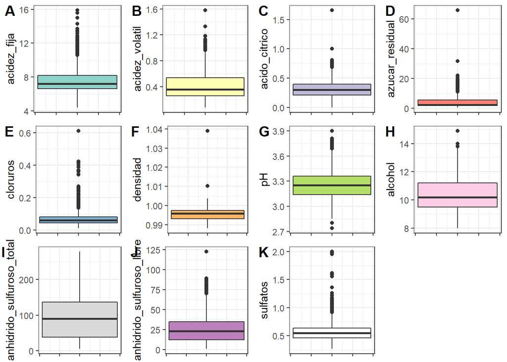

```r
ac_fij <- ggplot(Datos, aes(y=acidez_fija))+geom_boxplot(fill="#8DD3C7") + theme_bw()+theme(axis.text.x = element_blank())
ac_vol <- ggplot(Datos, aes(y=acidez_volatil))+geom_boxplot(fill="#FFFFB3") + theme_bw()+theme(axis.text.x = element_blank())
ac_cit <- ggplot(Datos, aes(y=acido_citrico))+geom_boxplot(fill="#BEBADA") + theme_bw()+theme(axis.text.x = element_blank())
az_res <- ggplot(Datos, aes(y=azucar_residual))+geom_boxplot(fill="#FB8072") + theme_bw()+theme(axis.text.x = element_blank())
clor<- ggplot(Datos, aes(y=cloruros))+geom_boxplot(fill="#80B1D3") + theme_bw()+theme(axis.text.x = element_blank())
dens <- ggplot(Datos, aes(y=densidad))+geom_boxplot(fill="#FDB462") + theme_bw()+theme(axis.text.x = element_blank())
ph <- ggplot(Datos, aes(y=pH))+geom_boxplot(fill="#B3DE69") + theme_bw()+theme(axis.text.x = element_blank())
alc <- ggplot(Datos, aes(y=alcohol))+geom_boxplot(fill="#FCCDE5") + theme_bw()+theme(axis.text.x = element_blank())
anh_tot <- ggplot(Datos, aes(y=anhidrido_sulfuroso_total))+geom_boxplot(fill="#D9D9D9") + theme_bw()+theme(axis.text.x = element_blank())
anh_libre <- ggplot(Datos, aes(y=anhidrido_sulfuroso_libre))+geom_boxplot(fill="#BC80BD") + theme_bw()+theme(axis.text.x = element_blank())
sulfatos <- ggplot(Datos, aes(y=sulfatos))+geom_boxplot(fill="white") + theme_bw()+theme(axis.text.x = element_blank())


plot_grid(ac_fij, ac_vol, ac_cit,az_res,clor, dens,ph,alc,anh_tot, anh_libre,sulfatos,labels = "AUTO")
```

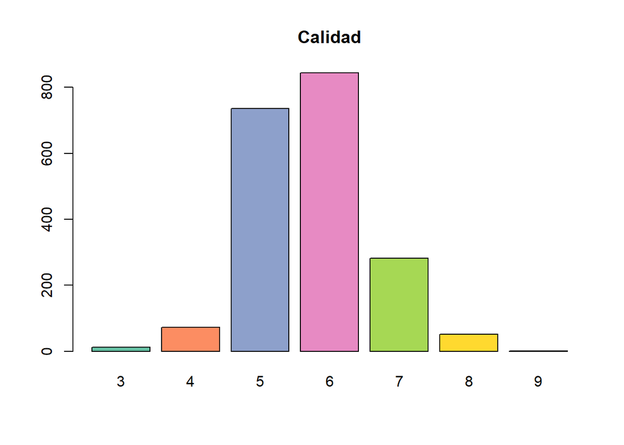

```r
calid <- barplot(table(Datos$calidad),beside=TRUE,col=brewer.pal(7,"Set2"), main="Calidad" )
```

### Ej.4

Presente una tabla de frecuencias y porcentaje para la variable calidad de vino según la variedad (tinto – blanco).

```r
tabla_frec_abs <- table(Datos$calidad, Datos$variedad)
colnames(tabla_frec_abs) <- c('tinto', "blanco")
rownames(tabla_frec_abs) <- c("calidad 3","calidad 4","calidad 5", "calidad 6",
                                 "calidad 7","calidad 8", "calidad 9")
tabla_frec_abs
```

```
##
##             tinto blanco
##   calidad 3     4      8
##   calidad 4    36     37
##   calidad 5   307    429
##   calidad 6   443    401
##   calidad 7   171    111
##   calidad 8    38     14
##   calidad 9     1      0
```

```r
tabla_frec_rel <- prop.table(tabla_frec_abs, 2)
colnames(tabla_frec_rel) <- c('tinto', "blanco")
rownames(tabla_frec_rel) <- c("calidad 3","calidad 4","calidad 5", "calidad 6",
                              "calidad 7","calidad 8", "calidad 9")
tabla_frec_rel
```

```
##
##             tinto blanco
##   calidad 3 0.004  0.008
##   calidad 4 0.036  0.037
##   calidad 5 0.307  0.429
##   calidad 6 0.443  0.401
##   calidad 7 0.171  0.111
##   calidad 8 0.038  0.014
##   calidad 9 0.001  0.000
```

### Ej.5

Realice un gráfico para representar la tabla construida en el punto 4

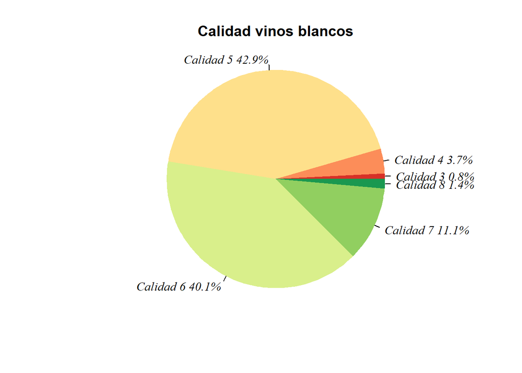

```r
datostintos=split(Datos,Datos$variedad)[[1]]
datosblancos=split(Datos,Datos$variedad)[[2]]

frec_blancos <- table(datosblancos$calidad)  # construye la distribución de frecuencias
frec_tintos <- table(datostintos$calidad)
# dibuja el diagrama circular
# Para VINOS BLANCOS
etiquetas<-c("Calidad 3","Calidad 4","Calidad 5", "Calidad 6",
             "Calidad 7","Calidad 8", "Calidad 9" ) # define etiquetas
pct_blanco<-round(frec_blancos/sum(frec_blancos)*100,2) # calcula las frecuencias porcentuales
etiquetas_blanco<-paste(etiquetas,pct_blanco) # agrega los porcentajes a las etiquetas
etiquetas_blanco<-paste(etiquetas_blanco,"%",sep="") # agrega el simbolo % a los porcentajes
pie(frec_blancos,labels =etiquetas_blanco, col=brewer.pal(6,"RdYlGn"),font=8,cex=1,radius=1,border=F,main="Calidad vinos blancos")
```

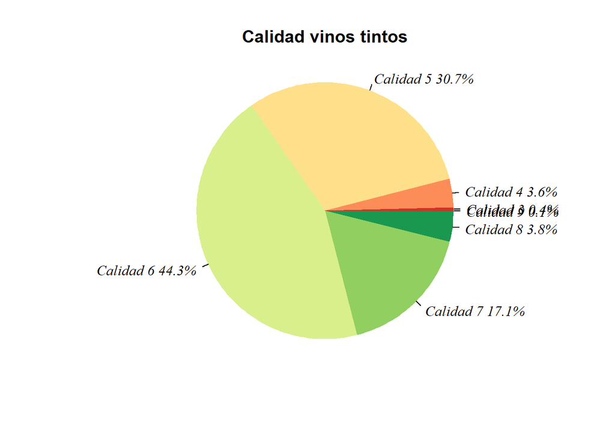

```r
# Para VINOS TINTOS
pct<-round(frec_tintos/sum(frec_tintos)*100,2) # calcula las frecuencias porcentuales
etiquetas_tinto<-paste(etiquetas,pct) # agrega los porcentajes a las etiquetas
etiquetas_tinto<-paste(etiquetas_tinto,"%",sep="") # agrega el simbolo % a los porcentajes
pie(frec_tintos,labels =etiquetas_tinto, col=brewer.pal(6,"RdYlGn"),font=8,cex=1,radius=1,border=F,main="Calidad vinos tintos")
```

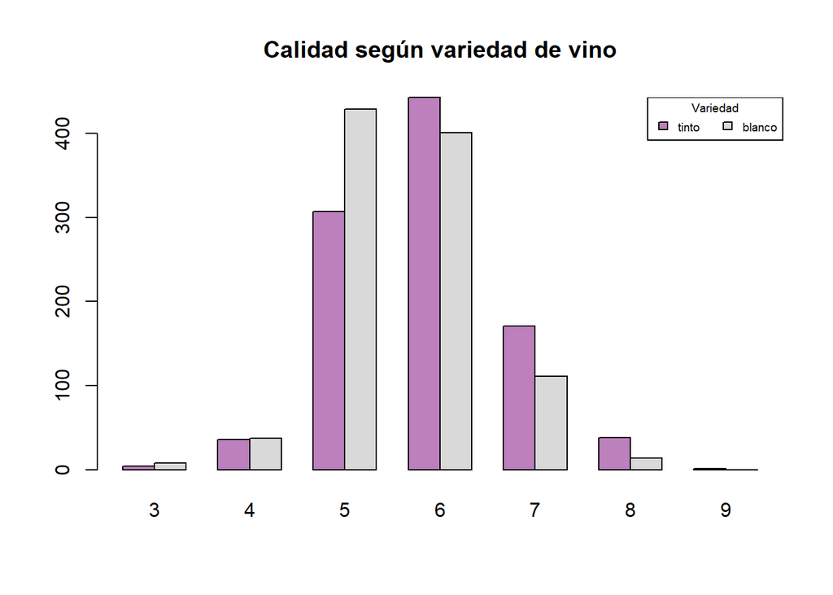

```r
#Gráfico de barras adyacentes
barplot(table(Datos$variedad,Datos$calidad),beside=TRUE,col=(c("#BC80BD","#D9D9D9")), main="Calidad según variedad de vino" )
legend("topright",cex=0.6,title="Variedad",c("tinto","blanco"),fill=(c("#BC80BD","#D9D9D9")),horiz=T) # asigna leyendas en posición horizontal
```

### Ej.6

Elija dos variables continuas, establezca rangos que representen distintos niveles de cada una y defina nuevas variables categóricas. Aplique un test adecuado para entender si existe asociación entre ambas. Utilice un nivel de significación del 5%.

```r
quantile(Datos$anhidrido_sulfuroso_total)
```

```
##   0%  25%  50%  75% 100%
##    6   38   90  137  278
```

```r
quantile(Datos$anhidrido_sulfuroso_libre)
```

```
##    0%   25%   50%   75%  100%
##   1.0  12.0  23.0  35.0 122.5
```

```r
Datos$anhidrido_sulfuroso_total_cuali <- cut(Datos$anhidrido_sulfuroso_total,
                breaks = c(5,100,500),labels = c('Bajo','Alto'))

Datos$anhidrido_sulfuroso_libre_cuali <- cut(Datos$anhidrido_sulfuroso_libre,
                                             breaks = c(0,30,300),labels = c('Bajo','Alto'))

#H0: el anhidrido_sulfuroso_libre es independiente de anhidrido_sulfuroso_total
#H1: las variables estan asociadas

# creo la tabla de contingencia
tabla <- table(Datos$anhidrido_sulfuroso_total_cuali, Datos$anhidrido_sulfuroso_libre_cuali)
colnames(tabla) = c("H2SO3 libre bajo", "H2SO3 libre alto")
rownames(tabla) = c("H2SO3 total bajo", "H2SO3 total alto")

chisq.test(tabla)$expected #se observa que la tabla de los observados difiere de la de las frecuencias esperadas
```

```
##
##                    H2SO3 libre bajo H2SO3 libre alto
##   H2SO3 total bajo         731.8405         371.1595
##   H2SO3 total alto         595.1595         301.8405
```

```r
chisq.test(tabla)   #Aplicación del test Chi-cuadrado
```

```
##
##  Pearson's Chi-squared test with Yates' continuity correction
##
## data:  tabla
## X-squared = 615.15, df = 1, p-value < 2.2e-16
```

```r
#analizo las subtablas de contingencia
Tab1<-tabla[,-1]
chisq.test(Tab1) #H2SO3 libre alto esta asociada con la cantidad de H2SO3 total
```

```
##
##  Chi-squared test for given probabilities
##
## data:  Tab1
## X-squared = 304.92, df = 1, p-value < 2.2e-16
```

```r
Tab2<-tabla[,-2]
chisq.test(Tab2) #H2SO3 libre bajo esta asociada con la cantidad de H2SO3 total
```

```
##
##  Chi-squared test for given probabilities
##
## data:  Tab2
## X-squared = 327.27, df = 1, p-value < 2.2e-16
```

## Ej 7 y 8

Seleccione otra variable continua y estime la diferencia de medias según la variedad del vino con un nivel de confianza del 95%. Interprete el resultado obtenido.

Según el resultado obtenido en el punto 7.- realice un test de hipótesis apropiado para determinar la diferencia de medias de la variable en estudio. Trabaje con una significación del 5%. Presente el planteo de hipótesis adecuado, la resolución y la decisión a tomar.

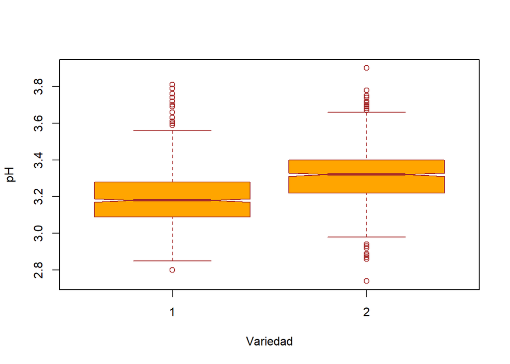

```r
boxplot(pH~variedad, data=Datos,
        xlab="Variedad",
        ylab="pH",
        col="orange",
        border="brown", notch=T)
```

```r
#intervalo confianza de ph para tintos y blancos
ph_tintos <- datostintos$pH
sd_tintos <- sd(ph_tintos)
mean_tintos <- mean(ph_tintos)
error <- qnorm(0.975)*sd_tintos/sqrt(1000)
IC_ph_tinto <- c(mean_tintos-error,mean_tintos+error)

ph_blancos <- datosblancos$pH
sd_blancos <- sd(ph_blancos)
mean_blancos <- mean(ph_blancos)
error <- qnorm(0.975)*sd_blancos/sqrt(1000)
IC_ph_blancos <- c(mean_blancos-error,mean_blancos+error)


#prueba de varianzas
var.test(pH~variedad, data=Datos, alternative = "two.sided") # es una prueba bilateral
```

```
##
##  F test to compare two variances
##
## data:  pH by variedad
## F = 1.0025, num df = 999, denom df = 999, p-value = 0.9679
## alternative hypothesis: true ratio of variances is not equal to 1
## 95 percent confidence interval:
##  0.8855488 1.1350037
## sample estimates:
## ratio of variances
##           1.002547
```

```r
# con un alfa de 0.05 no rechazo la H0 varianza de ambas variedades son iguales
shapiro.test(datosblancos$pH)
```

```
##
##  Shapiro-Wilk normality test
##
## data:  datosblancos$pH
## W = 0.99417, p-value = 0.0006313
```

```r
shapiro.test(datostintos$pH)
```

```
##
##  Shapiro-Wilk normality test
##
## data:  datostintos$pH
## W = 0.98214, p-value = 1.008e-09
```

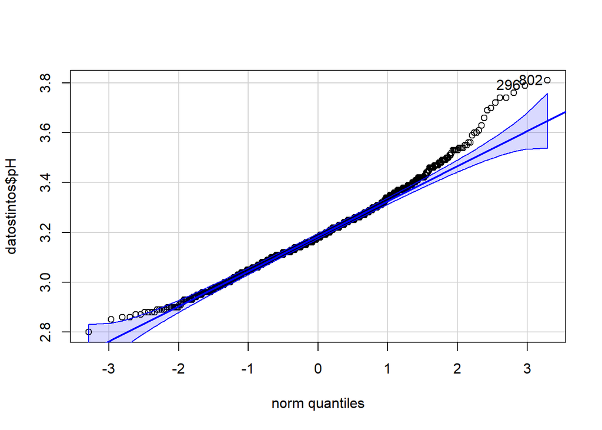

```
## [1] 802 296
```

```r
qqPlot(datostintos$pH)
```

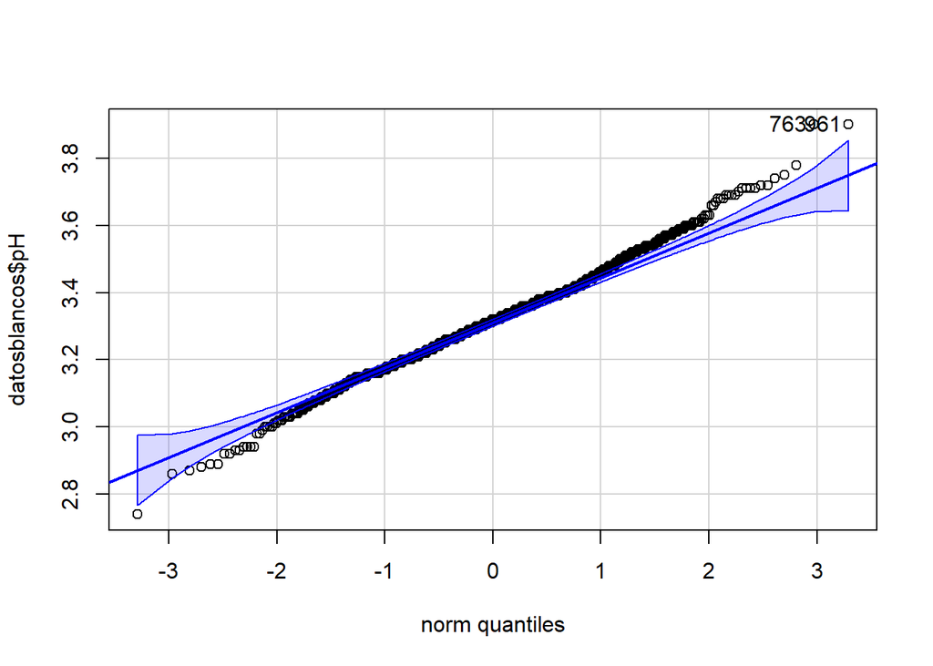

```
## [1] 763 961
```

```r
qqPlot(datosblancos$pH)
```

```r
wilcox.test(pH~variedad, data=Datos,alternative = "less")
```

```
##
##  Wilcoxon rank sum test with continuity correction
##
## data:  pH by variedad
## W = 265021, p-value < 2.2e-16
## alternative hypothesis: true location shift is less than 0
```

### Ej. 9

#### ¿Se puede afirmar que hay diferencias significativas en la calidad del vino tinto respecto al vino blanco? Elija un test de hipótesis adecuado. Trabaje con una significación del 5%.

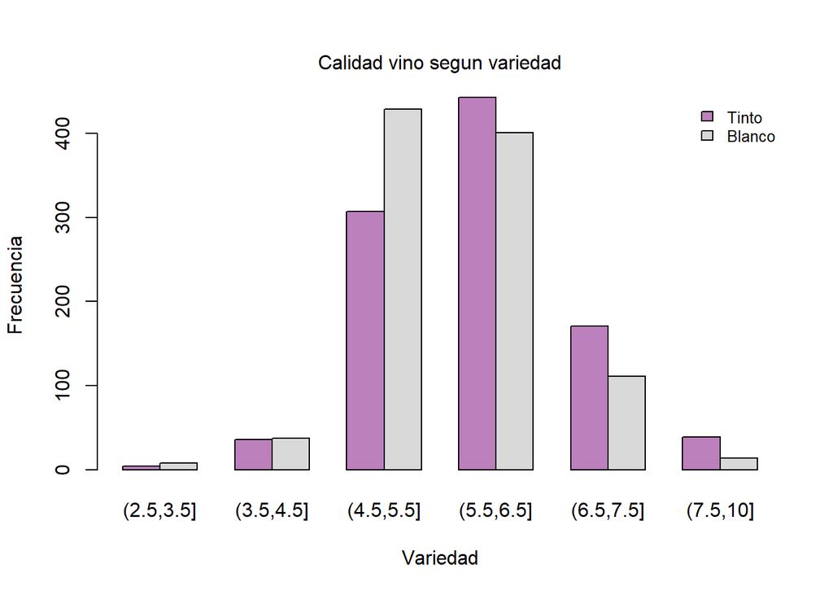

```r
Datos$calidad_cuali <- cut(Datos$calidad, breaks = c(2.5,3.5,4.5,5.5,6.5,7.5,10))

tabla_vino_calidad <- table(Datos$variedad , Datos$calidad_cuali )

barplot(tabla_vino_calidad,beside=TRUE,col= c("#BC80BD","#D9D9D9"),ylab="Frecuencia",xlab="Variedad")
mtext("Calidad vino segun variedad",cex=1,line=1)
legend("topright",cex=0.8,c("Tinto","Blanco"), fill=c("#BC80BD","#D9D9D9"),horiz=F, box.lty = 0)
```

```r
#aplico el test chi cuadrado
chisq.test(tabla_vino_calidad)
```

```
##
##  Pearson's Chi-squared test
##
## data:  tabla_vino_calidad
## X-squared = 48.218, df = 5, p-value = 3.205e-09
```

```r
#me fijo que todas las frecuencias esperadas tengan mas de cinco observaciones
chisq.test(tabla_vino_calidad)$expected
```

```
##
##     (2.5,3.5] (3.5,4.5] (4.5,5.5] (5.5,6.5] (6.5,7.5] (7.5,10]
##   1         6      36.5       368       422       141     26.5
##   2         6      36.5       368       422       141     26.5
```

```r
#realizo comparaciones post hoc
chisq.posthoc.test(tabla_vino_calidad, method = "bonferroni")
```

```
##   Dimension     Value (2.5,3.5]  (3.5,4.5] (4.5,5.5] (5.5,6.5] (6.5,7.5]
## 1         1 Residuals  -1.15818 -0.1192375  -5.65669  1.901578  3.855051
## 2         1  p values   1.00000  1.0000000   0.00000  0.686716  0.001388
## 3         2 Residuals   1.15818  0.1192375   5.65669 -1.901578 -3.855051
## 4         2  p values   1.00000  1.0000000   0.00000  0.686716  0.001388
##    (7.5,10]
## 1  3.480440
## 2  0.006007
## 3 -3.480440
## 4  0.006007
```

#### Ej. 10

Decida si existen diferencias significativas en las proporciones de alcohol entre los vinos de calidad baja, media y alta. Justifique..

```r
#la variable calidad la llevo a una variable de tres niveles

Datos$calidad_cuali <- cut(Datos$calidad, breaks = c(2.5,5,7,10))

modelo<-aov(alcohol ~ calidad_cuali, data=Datos)
summary(modelo)
```

```
##                 Df Sum Sq Mean Sq F value Pr(>F)
## calidad_cuali    2  492.5  246.27   231.7 <2e-16 ***
## Residuals     1997 2122.7    1.06
## ---
## Signif. codes:  0 '***' 0.001 '**' 0.01 '*' 0.05 '.' 0.1 ' ' 1
```

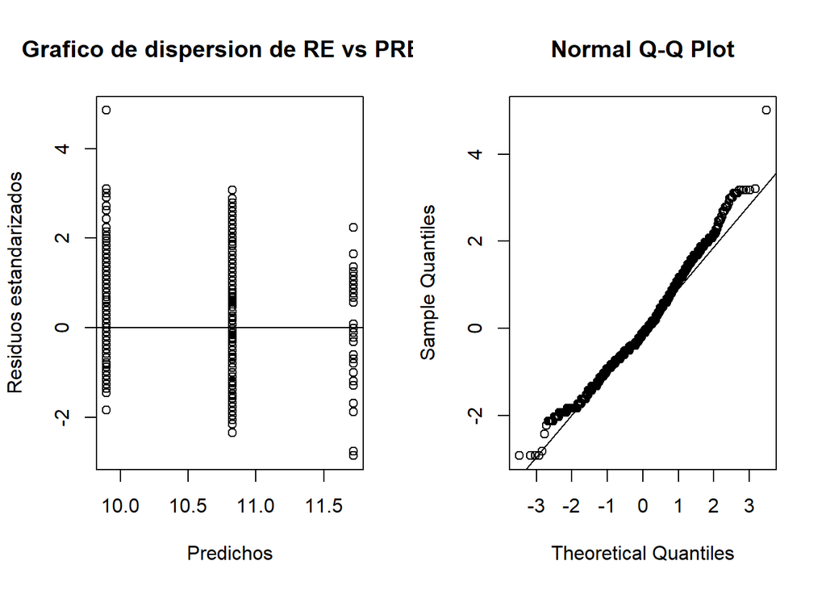

```r
#chequeo los supuestos del modelo
e<-resid(modelo) # residuos
re<-rstandard(modelo) #residuos estandarizados
pre<-predict(modelo) #predichos
res<-cbind(Datos$calidad_cuali,Datos$alcohol,pre,e,round(re,2))
colnames(res)<-c("calidad", "alcohol", "Predichos", "Residuos", "residuos std")
res<-as.data.frame(res)
par(mfrow = c(1, 2))
plot(pre, re, xlab="Predichos", ylab="Residuos estandarizados",main="Grafico de dispersion de RE vs PRED" )
abline(0,0)
qqnorm(e)
qqline(e)
```

```r
shapiro.test(e)
```

```
##
##  Shapiro-Wilk normality test
##
## data:  e
## W = 0.98487, p-value = 1.034e-13
```

```r
leveneTest(alcohol ~ calidad_cuali, data=Datos) #prueba de homogeneidad de varianzas
```

```
## Levene's Test for Homogeneity of Variance (center = median)
##         Df F value    Pr(>F)
## group    2    85.7 < 2.2e-16 ***
##       1997
## ---
## Signif. codes:  0 '***' 0.001 '**' 0.01 '*' 0.05 '.' 0.1 ' ' 1
```

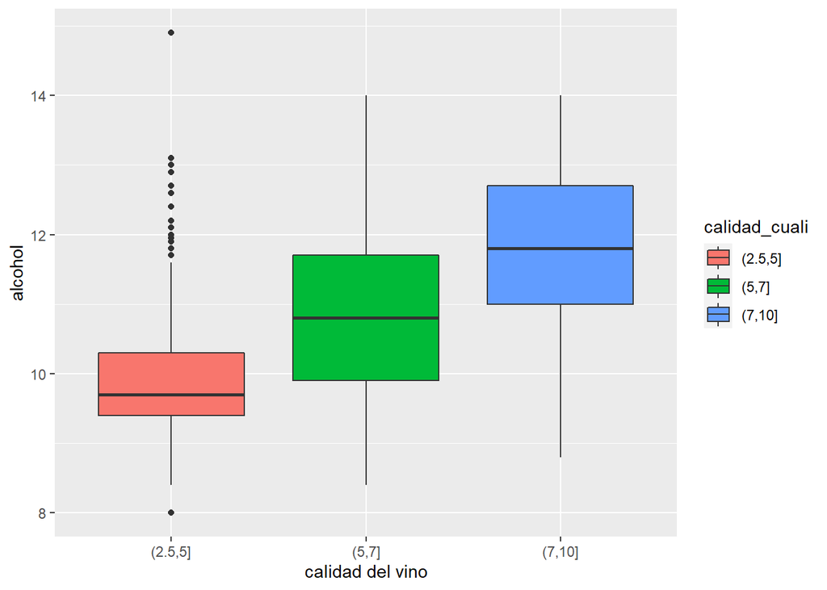

```r
ggplot(Datos,aes(x=calidad_cuali,y=alcohol,fill=calidad_cuali)) +
  geom_boxplot() +
  xlab("calidad del vino")
```

```r
kruskal.test(Datos$alcohol, Datos$calidad_cuali)
```

```
##
##  Kruskal-Wallis rank sum test
##
## data:  Datos$alcohol and Datos$calidad_cuali
## Kruskal-Wallis chi-squared = 370.64, df = 2, p-value < 2.2e-16
```

```r
kruskalmc(Datos$alcohol~Datos$calidad_cuali )
```

```
## Multiple comparison test after Kruskal-Wallis
## p.value: 0.05
## Comparisons
##                 obs.dif critical.dif difference
## (2.5,5]-(5,7]  478.3759     63.44693       TRUE
## (2.5,5]-(7,10] 812.5468    195.93617       TRUE
## (5,7]-(7,10]   334.1709    194.32030       TRUE
```